# Example workflow of scABC

Timothy Daley

4/30/2017

We’re going to walk through an example workflow for the scABC package, walking through all the individual steps of the analysis. We’ll use the 6 cell line mixture for an example. The 1632 cells can be downloaded from GEO under accession number GSE65360 (https://www.ncbi.nlm.nih.gov/geo/query/acc.cgi?acc=GSE65360).

## Pre-processing

We used Kundaje pipeline for aligning pair ended reads to hg19 and removing duplicates (https://github.com/kundajelab/atac_dnase_pipelines) with the command below for each read pair file.

```bash
bds_scr [SCR_NAME] atac.bds -align -species hg19 -species_file [SPECIES_FILE_PATH] -nth [NUM_THREADS] -fastq1_1 [READ_PAIR1] -fastq1_2 [READ_PAIR2]
```

For details on the pipeline, visit the Kundaje lab website or github page.

The resulting bam files were merged using samtools.

```bash
samtools merge [AGGREGATE_BAM] *.trim.PE2SE.nodup.bam
```

The merged bam file was then used as input into MACS2 to call merged peaks for later analysis, using the Kundaje pipeline again.

```bash
bds_scr [SCR_NAME] atac.bds -species hg19 -species_file [SPECIES_FILE_PATH] -nth [NUM_THREADS] -se -filt_bam [AGGREGATE_BAM]
```

Several of the cells have multiple runs. We merged these runs using samtools.

## Obtaining and filtering counts

We will use scABC to analyse the single cell data. The cell level bam files and their samtools indexes are contained in the folder bams.

```r
setwd("~/scRNAseqAnalysis/scATAC-RNAseq/scABC/vignettes/")
library(devtools)
devtools::install_github("timydaley/scABC", force = TRUE)
library(scABC)
# table that has experiment info
bamfile.table = read.table(file = "NoTreatment/6Lines/SRX&Type&Batch.txt")
head(bamfile.table)
```

```
##          V1    V2                   V3
## 1 SRX859035 H1ESC singles-H1ESC-well-1
## 2 SRX859036 H1ESC singles-H1ESC-well-2
## 3 SRX859037 H1ESC singles-H1ESC-well-3
## 4 SRX859038 H1ESC singles-H1ESC-well-4
## 5 SRX859039 H1ESC singles-H1ESC-well-5
## 6 SRX859040 H1ESC singles-H1ESC-well-6
```

```r
bamfiles = paste0("bams/", bamfile.table[,1], ".bam")
peaks = select_peaks("NoTreatment/6Lines/mergeAll.tn5.pf.gappedPeak")
dim(peaks)
```

```
## [1] 242875     15
```

Computing the Forground and Background matrix takes quite a bit of time. We can do this once and cache the results for later.

```r
ForeGround = get_counts_matrix(bamfiles, peaks);
```

```r
ForeGroundFiltered = filter_peaks(ForeGround$ForeGroundMatrix, peaks)
peaks = ForeGroundFiltered$peaks
```

```r
BackGround = get_background(bamfiles, peaks)
ForeGroundBackGroundFiltered = filter_samples(ForeGround = ForeGroundFiltered$ForeGroundMatrix, BackGround = BackGround$BackGroundMatrix)
InSilicoForeGround = ForeGroundBackGroundFiltered$ForeGroundMatrix
InSilicoBackGround = ForeGroundBackGroundFiltered$BackGroundMatrix
InSilicoPeaks = peaks
```

Now let’s compute the landmarks and take a look at them.

```r
InSilicoLandMarks = compute_landmarks(ForeGround = InSilicoForeGround,
                                      BackGround = InSilicoBackGround,
                                      nCluster = 6, lambda = 1, nTop = 2000)
# look at correlation between landmarks
cor(InSilicoLandMarks, InSilicoLandMarks, method = 'spearman')
```

```
##           [,1]      [,2]      [,3]      [,4]      [,5]      [,6]
## [1,] 1.0000000 0.5499138 0.4748952 0.4364145 0.4880086 0.4505189
## [2,] 0.5499138 1.0000000 0.5635555 0.4994078 0.6456894 0.4927121
## [3,] 0.4748952 0.5635555 1.0000000 0.4953581 0.5454351 0.4370819
## [4,] 0.4364145 0.4994078 0.4953581 1.0000000 0.4831819 0.4262173
## [5,] 0.4880086 0.6456894 0.5454351 0.4831819 1.0000000 0.4520639
## [6,] 0.4505189 0.4927121 0.4370819 0.4262173 0.4520639 1.0000000
```

It looks like the cluster landmarks are well seperated. Let’s look at the cell to cluster assignments.

```r
# assign cells to the closest landmark
InSilicoLandMarkAssignments = assign2landmarks(InSilicoForeGround, InSilicoLandMarks)
InSilicoCell2LandmarkCorrelation = cbind(apply(InSilicoForeGround, 2, function(x) cor(x, InSilicoLandMarks[,1], method = 'spearman')),
                                         apply(InSilicoForeGround, 2, function(x) cor(x, InSilicoLandMarks[,2], method = 'spearman')),
                                         apply(InSilicoForeGround, 2, function(x) cor(x, InSilicoLandMarks[,3], method = 'spearman')),
                                         apply(InSilicoForeGround, 2, function(x) cor(x, InSilicoLandMarks[,4], method = 'spearman')),
                                         apply(InSilicoForeGround, 2, function(x) cor(x, InSilicoLandMarks[,5], method = 'spearman')),
                                         apply(InSilicoForeGround, 2, function(x) cor(x, InSilicoLandMarks[,6], method = 'spearman')))
cell.info = bamfile.table[which(paste0(bamfile.table[,1], ".bam") %in% colnames(InSilicoForeGround)), 2]
library(gplots)
library(RColorBrewer)
library(devtools)
source_url("https://raw.githubusercontent.com/obigriffith/biostar-tutorials/master/Heatmaps/heatmap.3.R")
```

```
## SHA-1 hash of file is 015fc0457e61e3e93a903e69a24d96d2dac7b9fb
```

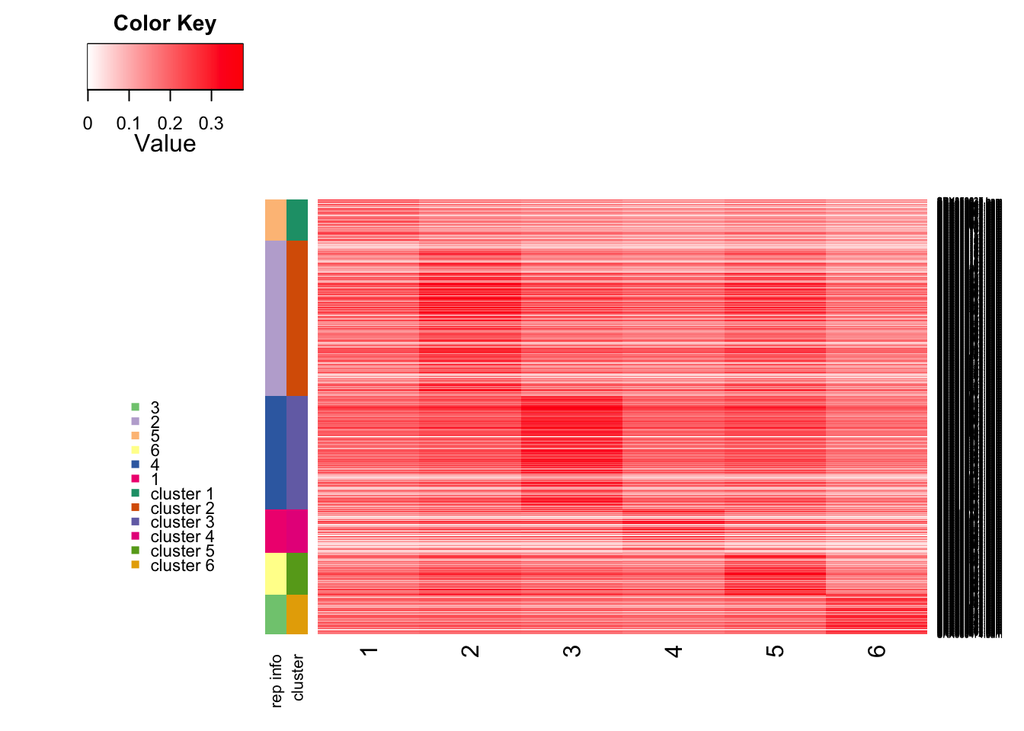

```r
scalered <- colorRampPalette(c("white", "red"), space = "rgb")(256)
rcols1 = brewer.pal(6, "Accent")[1:6]
rowcols1 = rcols1[cell.info]
rcols2 = brewer.pal(6, "Dark2")[1:6]
rowcols2 = rcols2[InSilicoLandMarkAssignments]
rowcols = rbind(rowcols1, rowcols2)
rownames(rowcols) = c("rep info", "cluster")
heatmap.3(InSilicoCell2LandmarkCorrelation, dendrogram='none', Rowv=FALSE, Colv=FALSE,
          trace='none', col = scalered, margin = c(5, 5), density.info = "none",
          RowSideColors = rowcols, RowSideColorsSize=2, symm=F,symkey=F,
          symbreaks=F, scale="none")
legend("bottomleft", legend = c(unique(cell.info), paste0("cluster ", 1:6)), col = c(rcols1, rcols2), border=FALSE, bty="n", y.intersp = 0.7, cex=0.7, pch = 15)
```

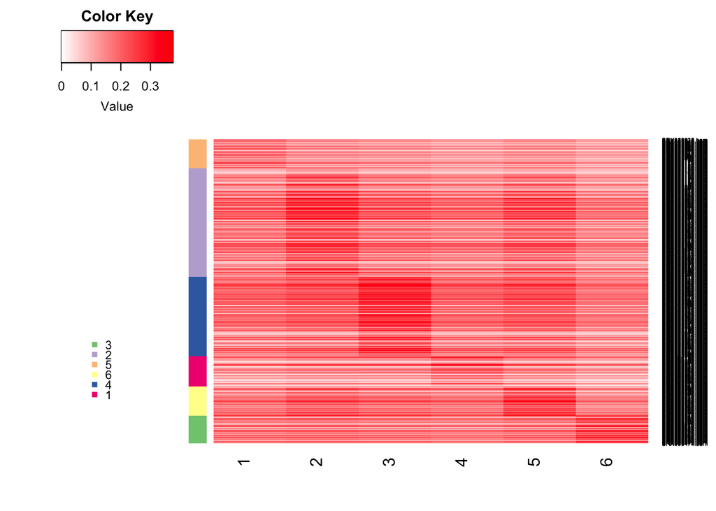

```r
heatmap.2(InSilicoCell2LandmarkCorrelation, dendrogram='none', Rowv=FALSE,
          Colv=FALSE, trace='none', col = scalered, margin = c(5, 5),
          density.info = "none", RowSideColors = rowcols1, symm=F,
          symkey=F,symbreaks=F, scale="none")
legend("bottomleft", legend = c(unique(cell.info)), col = rcols1, border=FALSE,
       bty="n", y.intersp = 0.7, cex=0.7, pch = 15)
```

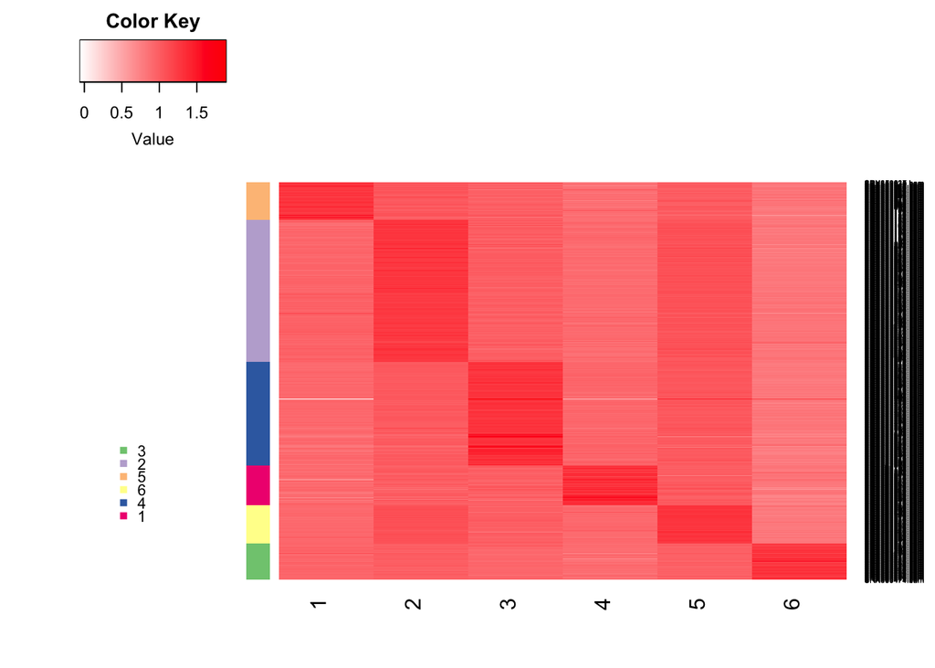

```r
for(i in 1:dim(InSilicoCell2LandmarkCorrelation)[1]){
  InSilicoCell2LandmarkCorrelation[i,] = InSilicoCell2LandmarkCorrelation[i,]/mean(InSilicoCell2LandmarkCorrelation[i,])
}
library(gplots)
library(RColorBrewer)
heatmap.2(InSilicoCell2LandmarkCorrelation, dendrogram='none', Rowv=FALSE, Colv=FALSE, trace='none', col = scalered, margin = c(5, 5), density.info = "none",
          RowSideColors = rowcols1, symm=F,symkey=F,symbreaks=F, scale="none")
legend("bottomleft", legend = c(unique(cell.info)), col = rcols1, border=FALSE,
       bty="n", y.intersp = 0.7, cex=0.7, pch = 15)
```

The clustering correctly classifies all cells except for 1. This assumes we knew the number of clusters. What if we let scABC choose the number of clusters?

```r
InSilicoBackGroundMedian = apply(InSilicoBackGround, 2, median)
InSilicoGapStat = getGapStat(InSilicoForeGround, InSilicoBackGroundMedian,
                             nClusters=1:10, nPerm = 20, quiet = TRUE)
InSilicoGapStat$nClusterOptimal
```

```
## [1] 6
```

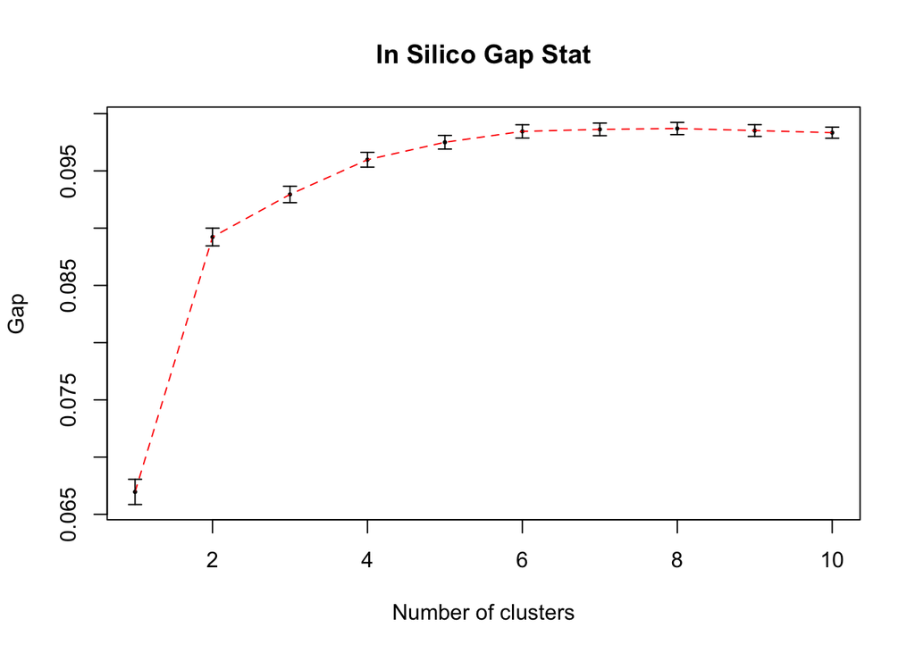

```
## [1] 1
```

```r
plotGapStat(InSilicoGapStat, nClusters = 1:10, main = "In Silico Gap Stat")
```

scABC chooses 6 clusters and we can continue with this number of clusters.

```r
InSilicoPeakSelection = getClusterSpecificPvalue(ForeGround=InSilicoForeGround, cluster_assignments = InSilicoLandMarkAssignments, background_medians = InSilicoBackGroundMedian)
```

[output not shown]

[output cut: 49 more lines]

```r
InSilicoPeakPvals = InSilicoPeakSelection$pvalue
head(InSilicoPeakPvals)
```

```
##         Cluster 1 Cluster 2    Cluster 3    Cluster 4 Cluster 5 Cluster 6
## [1,] 1.000000e+00 1.0000000 1.000000e+00 2.325067e-48 1.0000000 1.0000000
## [2,] 3.134483e-07 0.9999997 1.000000e+00 1.000000e+00 1.0000000 1.0000000
## [3,] 1.000000e+00 1.0000000 0.000000e+00 1.000000e+00 1.0000000 1.0000000
## [4,] 9.701213e-01 0.9621131 3.788687e-02 9.996608e-01 0.9948569 0.9974671
## [5,] 9.994836e-01 0.9870934 5.277733e-02 9.472227e-01 0.9999959 0.9975895
## [6,] 9.999988e-01 0.9999994 4.079405e-06 9.999992e-01 0.9999962 0.9999959
```

Let’s visualize the data.

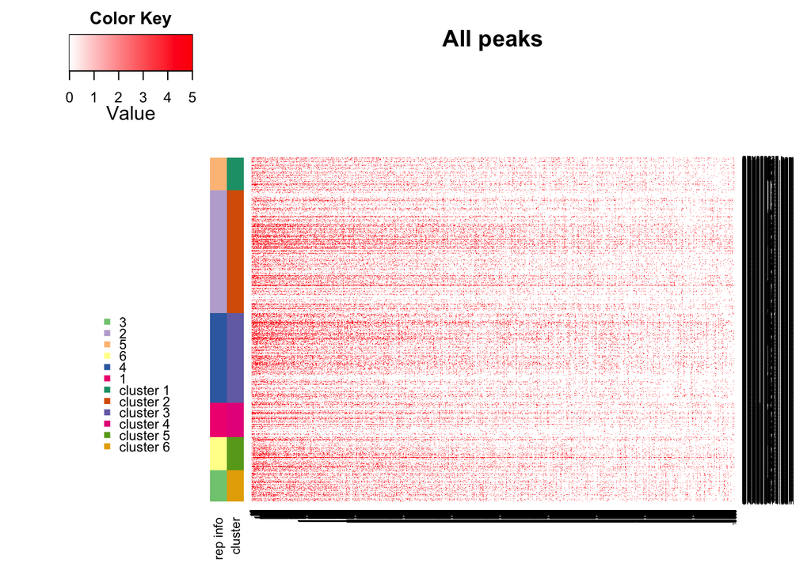

```r
# all peaks
scalered <- colorRampPalette(c("white", "red"), space = "rgb")(256)
rcols1 = brewer.pal(6, "Accent")[1:6]
rowcols1 = rcols1[cell.info]
rcols2 = brewer.pal(6, "Dark2")[1:6]
rowcols2 = rcols2[InSilicoLandMarkAssignments]
rowcols = rbind(rowcols1, rowcols2)
rownames(rowcols) = c("rep info", "cluster")
x = t(InSilicoForeGround)
x = x[ ,head(order(rowSums(InSilicoForeGround), decreasing = TRUE), 10000)]
d = as.dist(1 - cor(x, method = "spearman"))
col.clus = hclust(d, method ="average")
#truncate to see patterns
x[which(x > 5)] = 5
heatmap.3(x, dendrogram='none', Rowv=FALSE, Colv=col.clus, trace='none', col = scalered,
          margin = c(5, 5), density.info = "none", RowSideColors = rowcols,
          RowSideColorsSize=2, main = "All peaks")
legend("bottomleft", legend = c(unique(cell.info), paste0("cluster ", 1:6)),
       col = c(rcols1, rcols2), border=FALSE, bty="n", y.intersp = 0.7, cex=0.7, pch = 15)
```

We’ll select the cluster specific peaks by selecting the 10,000 peaks with the smallest p-values across all clusters.

```r
# cluster specific peaks
ClusterSpecificPeaks = head(order(apply(InSilicoPeakPvals, 1, min),
                                  decreasing = FALSE), 10000)
length(ClusterSpecificPeaks)
```

```
## [1] 10000
```

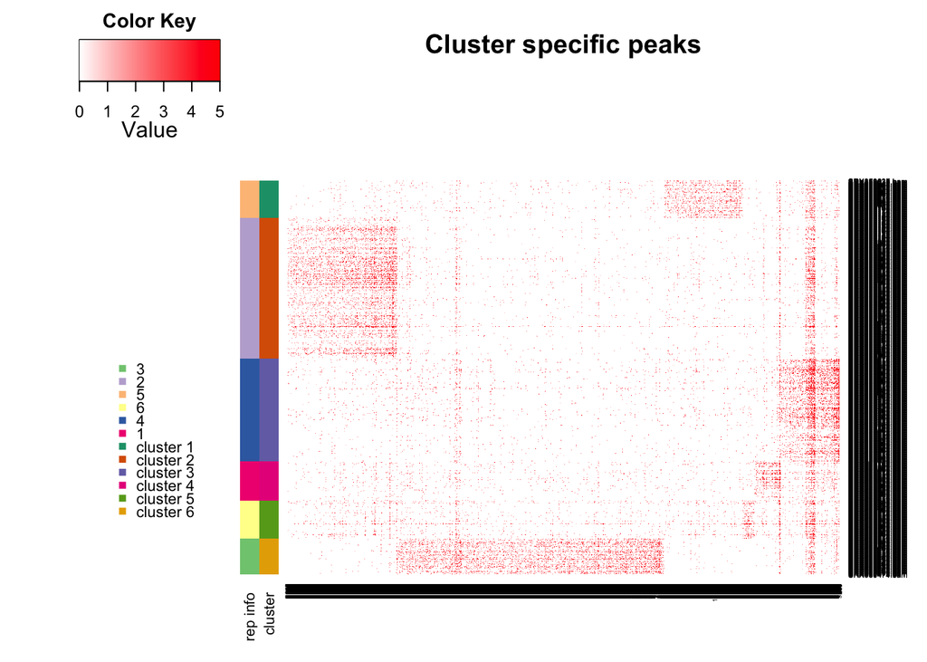

```r
x = t(InSilicoForeGround[ClusterSpecificPeaks, ])
d = as.dist(1 - cor(x, method = "spearman"))
col.clus = hclust(d, method ="average")
#truncate to see patterns
x[which(x > 5)] = 5
heatmap.3(x, dendrogram='none', Rowv=FALSE, Colv=as.dendrogram(col.clus), trace='none',
          col = scalered, margin = c(5, 5), density.info = "none", RowSideColors = rowcols,
          RowSideColorsSize=2, main = "Cluster specific peaks")
legend("bottomleft", legend = c(unique(cell.info), paste0("cluster ", 1:6)),
       col = c(rcols1, rcols2), border=FALSE, bty="n", y.intersp = 0.7, cex=0.7, pch = 15)
```

Instead of all of the above commands to obtain the clustered and processed data, we can simply use the scABC command to do all of the above.

```r
source("~/scRNAseqAnalysis/scATAC-RNAseq/scABC/R/scABC.R")
library(GenomicRanges)
library(Rsamtools)
library(WeightedCluster)
peakfile = "NoTreatment/6Lines/mergeAll.tn5.pf.gappedPeak"
bamfile.table = read.table(file = "NoTreatment/6Lines/SRX&Type&Batch.txt")
bamfiles = paste0("bams/", bamfile.table[,1], ".bam")
InSilicoSCABC = scABC(bamfiles, peakfile)
```

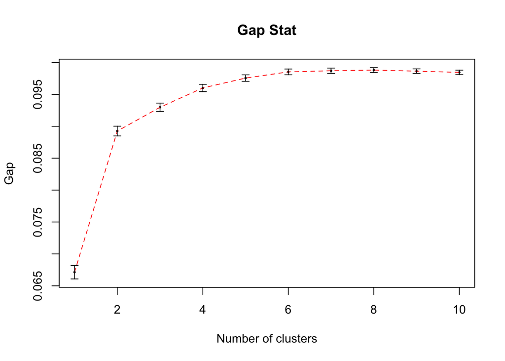

We’ll subset a selection of peaks to look at top 10,000 cluster specific peaks.

```r
ClusterSpecificPeaksV2 = head(order(apply(InSilicoSCABC$PeakPVals, 1, min),
                                    decreasing = FALSE), 10000)
length(intersect(ClusterSpecificPeaks, ClusterSpecificPeaksV2))
```

```
## [1] 10000
```

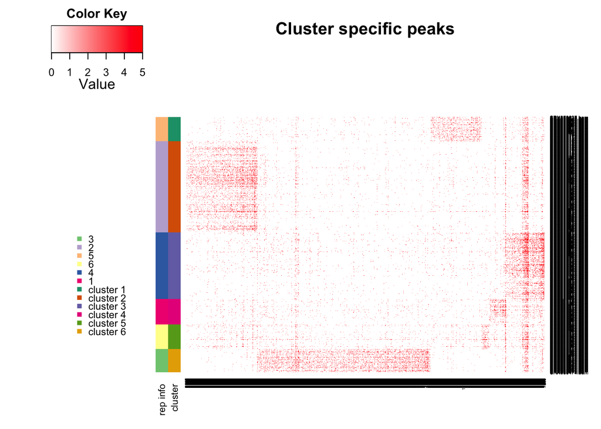

```r
# all peaks are cluster specific
scalered <- colorRampPalette(c("white", "red"), space = "rgb")(256)
rcols1 = brewer.pal(6, "Accent")[1:6]
rowcols1 = rcols1[cell.info]
rcols2 = brewer.pal(6, "Dark2")[1:6]
rowcols2 = rcols2[InSilicoSCABC$cluster_assignments]
rowcols = rbind(rowcols1, rowcols2)
rownames(rowcols) = c("rep info", "cluster")
x = t(InSilicoSCABC$ForeGroundMatrix[ClusterSpecificPeaksV2, ])
d = as.dist(1 - cor(x, method = "spearman"))
col.clus = hclust(d, method ="average")
x[which(x > 5)] = 5
heatmap.3(x, dendrogram='none', Rowv=FALSE, Colv=as.dendrogram(col.clus), trace='none',
          col = scalered, margin = c(5, 5), density.info = "none", RowSideColors = rowcols,
          RowSideColorsSize=2, main = "Cluster specific peaks")
legend("bottomleft", legend = c(unique(cell.info), paste0("cluster ", 1:6)),
       col = c(rcols1, rcols2), border=FALSE, bty="n", y.intersp = 0.7, cex=0.7, pch = 15)
```

We can also select cluster specific peaks by taking peaks that are less than some threshhold. We have to set it to be really small because Rmarkdown does not support large matrices.

```r
ClusterSpecificPeaksV3 = which(apply(InSilicoSCABC$PeakPVals, 1, min) < 0.0001)
length(ClusterSpecificPeaksV3)
```

```
## [1] 19009
```

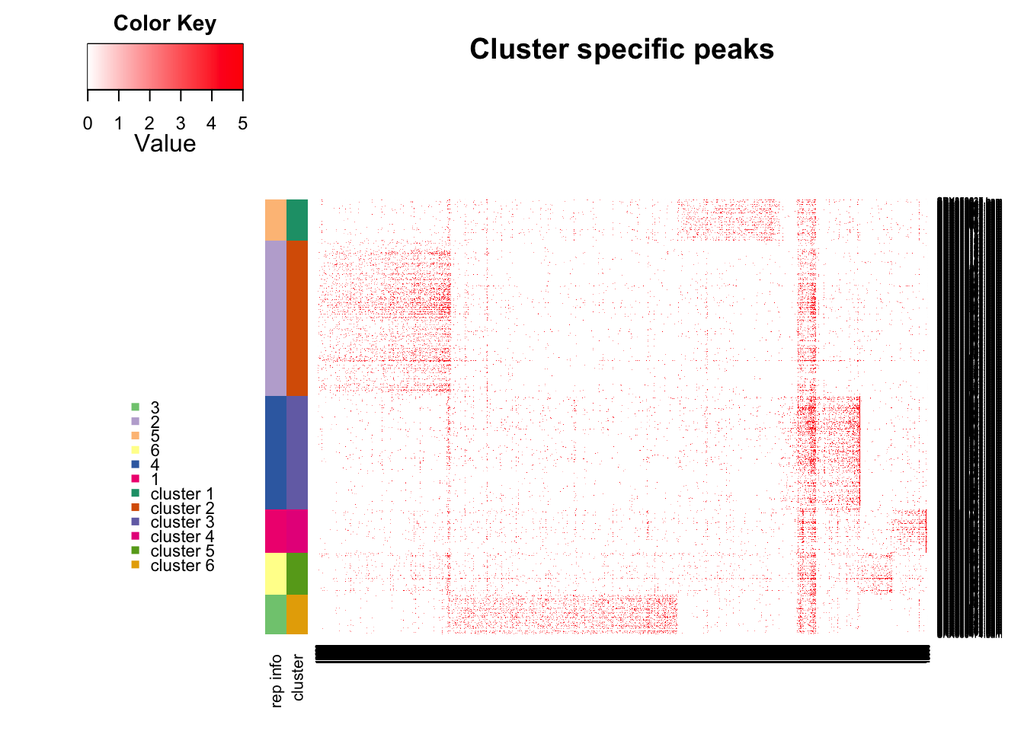

```r
# all peaks are cluster specific
scalered <- colorRampPalette(c("white", "red"), space = "rgb")(256)
rcols1 = brewer.pal(6, "Accent")[1:6]
rowcols1 = rcols1[cell.info]
rcols2 = brewer.pal(6, "Dark2")[1:6]
rowcols2 = rcols2[InSilicoSCABC$cluster_assignments]
rowcols = rbind(rowcols1, rowcols2)
rownames(rowcols) = c("rep info", "cluster")
x = t(InSilicoSCABC$ForeGroundMatrix[ClusterSpecificPeaksV3, ])
d = as.dist(1 - cor(x, method = "spearman"))
col.clus = hclust(d, method ="average")
x[which(x > 5)] = 5
heatmap.3(x, dendrogram='none', Rowv=FALSE, Colv=as.dendrogram(col.clus),
          trace='none', col = scalered, margin = c(5, 5), density.info = "none",
          RowSideColors = rowcols, RowSideColorsSize=2, main = "Cluster specific peaks")
legend("bottomleft", legend = c(unique(cell.info), paste0("cluster ", 1:6)),
       col = c(rcols1, rcols2), border=FALSE, bty="n", y.intersp = 0.7, cex=0.7, pch = 15)
```